# Summer School: Enrollment, continuation, and attainment

Bek Rengel

2025-11-26

# 1 OVERVIEW

This notebook demonstrates the workflow used to evaluate the impact of the **Access to UWE Bristol Summer School**, as part of UWE’s Access and Participation Plan. Specifically this analysis focused on exploring the impact of the Summer School attendance on enrollment at the institution, continuation among those who enrolled, and first year academic attainment.

> This notebook uses **synthetic data** randomly generated to reproduce **patterns** observed during the analysis rather than original values. This is to comply with GDPR and ethical requirements of this research, ensuring the data contains no personal or identifiable information.

For more information on this study, please see the README documents. To read evaluation reports, please visit [UWE Bristol’s Access and Participation Plan Pages.](https://www.uwe.ac.uk/about/values-vision-strategy/equality-diversity-and-inclusivity/policies#a7060a79c-a095-4fac-b16d-bd2e100068a9) You will find reports relating to this evaluation listed under the ‘Widening Access and Raising Attainment’ section. Please note some reports are forthcoming in early 2026.

**Copyright notice** © University of the West of England, Bristol (UWE Bristol), November 2025. Original author: Bek Rengel. All rights reserved.

```r
library(dplyr)
```

```r
library(tidyr)
library(ggplot2)
library(rstanarm)
```

# 2 Synthetic data generation

The original study used a quasi-experimental design comprising two groups:

- Intervention group (IG) who attended the Summer School
- Comparison group (CG) who did not attend.

The synthetic data reproduces key structural features of the original dataset, where possible, including:

- group sizes
- enrollment probabilities
- continuation probabilities
- average module marks based on original means and standard deviations for each group (pass rate has been fully randomised for simplicity and is not based on original data)
- one selected contextual covariate used in later modelling to explore the impact of potential confounders.

Academic outcomes included:

- **Enrollment**: whether participants enrolled at the institution where the study took place.
- **Continuation**: whether enrolled participants continued into the next year of study and is adapted from an institutional measure.
- **Attainment proxies**: average module mark and average module pass rate for enrolled participants.

One additional synthetic variable was included to demonstrate covariate handling in models:

- **Survey score** (Likert 1-5) for one pre-activity survey question, asking participants about their confidence to achieve the grades required to progress to university.

Please note in the original study, average mark was calculated for each individual enrolled participant. Where an individual undertook a resit, resit marks were taken as final. Any modules that did not have a numeric grade but were instead ungraded pass/fail were excluded from the average mark but were used to calculate each student’s module pass rate. Average marks were weighted based on module credit. Pass rate was calculated for each individual enrolled participant, showing the proportion of modules they passed. Where an individual undertook a resit, resit pass/fail was taken. Ungraded pass/fail modules were included in pass rate.

```r
set.seed(123)

#IG dataset ######################################################
n_IG <- 22
enrol_probs_IG <- c("not enrolled" = 0.14, "enrolled" = 0.86) # proportions rounded from original data
cont_probs_IG <- c("not continued" = 0.05, "continued" = 0.95) # proportions for those who enrolled, rounded from original data

enrollment_IG <- sample(names(enrol_probs_IG), size = n_IG, replace = TRUE, prob = enrol_probs_IG)

continued_IG <- character(n_IG)
for (i in seq_len(n_IG)) {
  if (enrollment_IG[i] == "enrolled") {
    continued_IG[i] <- sample(names(cont_probs_IG),
                              size = 1,
                              replace = TRUE,
                              prob = cont_probs_IG)
  } else {
    continued_IG[i] <- "not enrolled"
  }
}

likert_mean_IG <- 3.55 #mean survey score from original study
likert_sd_IG <- 0.9 #standard deviation for survey score from original study

IG_df <- data.frame(
  study_id = paste0("IG", seq_len(n_IG)),
  study_group = "IG",
  enrollment = enrollment_IG,
  continued = continued_IG,
  stringsAsFactors = FALSE) %>%
  mutate(
    avg_mark = if_else(enrollment == "enrolled", round(rnorm(n(), mean = 57.2, sd = 14.9), 1), NA_real_),
    avg_pass_rate = if_else(enrollment == "enrolled", round(runif(n(), min = 0, max = 100), 1), NA_real_),
    survey_score = rnorm(n(), mean = likert_mean_IG, sd = likert_sd_IG),
    survey_score = pmin(pmax(round(survey_score), 1), 5)
  )

head(IG_df, 10)
```

```
##    study_id study_group   enrollment     continued avg_mark avg_pass_rate
## 1       IG1          IG     enrolled     continued     45.5          66.8
## 2       IG2          IG     enrolled not continued     46.3          41.8
## 3       IG3          IG     enrolled     continued     54.0          78.8
## 4       IG4          IG not enrolled  not enrolled       NA            NA
## 5       IG5          IG not enrolled  not enrolled       NA            NA
## 6       IG6          IG     enrolled     continued     55.9          98.5
## 7       IG7          IG     enrolled     continued     73.2          89.3
## 8       IG8          IG not enrolled  not enrolled       NA            NA
## 9       IG9          IG     enrolled     continued     39.8          17.5
## 10     IG10          IG     enrolled     continued     45.0          13.1
##    survey_score
## 1             5
## 2             5
## 3             4
## 4             3
## 5             3
## 6             5
## 7             3
## 8             5
## 9             3
## 10            3
```

```r
str(IG_df)
```

```
## 'data.frame':    22 obs. of  7 variables:
##  $ study_id     : chr  "IG1" "IG2" "IG3" "IG4" ...
##  $ study_group  : chr  "IG" "IG" "IG" "IG" ...
##  $ enrollment   : chr  "enrolled" "enrolled" "enrolled" "not enrolled" ...
##  $ continued    : chr  "continued" "not continued" "continued" "not enrolled" ...
##  $ avg_mark     : num  45.5 46.3 54 NA NA 55.9 73.2 NA 39.8 45 ...
##  $ avg_pass_rate: num  66.8 41.8 78.8 NA NA 98.5 89.3 NA 17.5 13.1 ...
##  $ survey_score : num  5 5 4 3 3 5 3 5 3 3 ...
```

```r
#CG dataset ########################################################
n_CG <- 50
enrol_probs_CG <- c("not enrolled" = 0.40, "enrolled" = 0.60) # proportions rounded from original data
cont_probs_CG <- c("not continued" = 0.133, "continued" = 0.867) # proportions for those who enrolled, rounded from original data

enrollment_CG <- sample(names(enrol_probs_CG), size = n_CG, replace = TRUE, prob = enrol_probs_CG)

continued_CG <- character(n_CG)
for (i in seq_len(n_CG)) {
  if (enrollment_CG[i] == "enrolled") {
    continued_CG[i] <- sample(names(cont_probs_CG),
                              size = 1,
                              replace = TRUE,
                              prob = cont_probs_CG)
  } else {
    continued_CG[i] <- "not enrolled"
  }
}

likert_mean_CG <- 4.10 # mean survey score from original data
likert_sd_CG <- 0.8 #sd survey score from original data

CG_df <- data.frame(
  study_id = paste0("CG", seq_len(n_CG)),
  study_group = "CG",
  enrollment = enrollment_CG,
  continued = continued_CG,
  stringsAsFactors = FALSE) %>%
  mutate(
    avg_mark = if_else(enrollment == "enrolled", round(rnorm(n(), mean = 60.1, sd = 17.1), 1), NA_real_),
    avg_pass_rate = if_else(enrollment == "enrolled", round(runif(n(), min = 0, max = 100), 1), NA_real_),
    survey_score = rnorm(n(), mean = likert_mean_CG, sd = likert_sd_CG),
    survey_score = pmin(pmax(round(survey_score), 1), 5)
  )
head(CG_df, 10)
```

```
##    study_id study_group   enrollment     continued avg_mark avg_pass_rate
## 1       CG1          CG     enrolled     continued     65.2          61.7
## 2       CG2          CG     enrolled     continued     61.9          28.6
## 3       CG3          CG not enrolled  not enrolled       NA            NA
## 4       CG4          CG not enrolled  not enrolled       NA            NA
## 5       CG5          CG     enrolled     continued     42.6          31.4
## 6       CG6          CG     enrolled     continued     62.1          49.3
## 7       CG7          CG     enrolled not continued     43.9          69.7
## 8       CG8          CG     enrolled     continued     51.7          64.1
## 9       CG9          CG     enrolled     continued     55.7          64.4
## 10     CG10          CG     enrolled     continued     91.6          97.8
##    survey_score
## 1             4
## 2             4
## 3             4
## 4             3
## 5             3
## 6             5
## 7             5
## 8             3
## 9             4
## 10            3
```

```r
str(CG_df)
```

```
## 'data.frame':    50 obs. of  7 variables:
##  $ study_id     : chr  "CG1" "CG2" "CG3" "CG4" ...
##  $ study_group  : chr  "CG" "CG" "CG" "CG" ...
##  $ enrollment   : chr  "enrolled" "enrolled" "not enrolled" "not enrolled" ...
##  $ continued    : chr  "continued" "continued" "not enrolled" "not enrolled" ...
##  $ avg_mark     : num  65.2 61.9 NA NA 42.6 62.1 43.9 51.7 55.7 91.6 ...
##  $ avg_pass_rate: num  61.7 28.6 NA NA 31.4 49.3 69.7 64.1 64.4 97.8 ...
##  $ survey_score : num  4 4 4 3 3 5 5 3 4 3 ...
```

```r
#combined dataset #################################################################
combined_df <- CG_df %>%
  bind_rows(IG_df)
head(combined_df, 10)
```

```
##    study_id study_group   enrollment     continued avg_mark avg_pass_rate
## 1       CG1          CG     enrolled     continued     65.2          61.7
## 2       CG2          CG     enrolled     continued     61.9          28.6
## 3       CG3          CG not enrolled  not enrolled       NA            NA
## 4       CG4          CG not enrolled  not enrolled       NA            NA
## 5       CG5          CG     enrolled     continued     42.6          31.4
## 6       CG6          CG     enrolled     continued     62.1          49.3
## 7       CG7          CG     enrolled not continued     43.9          69.7
## 8       CG8          CG     enrolled     continued     51.7          64.1
## 9       CG9          CG     enrolled     continued     55.7          64.4
## 10     CG10          CG     enrolled     continued     91.6          97.8
##    survey_score
## 1             4
## 2             4
## 3             4
## 4             3
## 5             3
## 6             5
## 7             5
## 8             3
## 9             4
## 10            3
```

```r
str(combined_df)
```

```
## 'data.frame':    72 obs. of  7 variables:
##  $ study_id     : chr  "CG1" "CG2" "CG3" "CG4" ...
##  $ study_group  : chr  "CG" "CG" "CG" "CG" ...
##  $ enrollment   : chr  "enrolled" "enrolled" "not enrolled" "not enrolled" ...
##  $ continued    : chr  "continued" "continued" "not enrolled" "not enrolled" ...
##  $ avg_mark     : num  65.2 61.9 NA NA 42.6 62.1 43.9 51.7 55.7 91.6 ...
##  $ avg_pass_rate: num  61.7 28.6 NA NA 31.4 49.3 69.7 64.1 64.4 97.8 ...
##  $ survey_score : num  4 4 4 3 3 5 5 3 4 3 ...
```

# 3 Descriptive statistics

Descriptive statistics are presented to contextualise group differences prior to modelling. These summaries are intended as sense checks rather than inferential results, and values are synthetic and illustrative only.

In the original study, IG participants enrolled and continued with their studies at a higher proportion than CG, and there was very little difference between the groups in average mark and pass rate.

To see actual results from the study, please visit the link to the evaluation reports in the ‘Overview’ section.

```r
descriptives <- list(
  Enrollment = combined_df %>%
    group_by(study_group, enrollment) %>%
    summarise(n_enrolled = n()) %>%
    mutate(perc_enrolled = round(n_enrolled/ sum(n_enrolled) *100, 1)),
  Continuation = combined_df %>%
    group_by(study_group, continued) %>%
    filter(continued != "not enrolled") %>%
    summarise(n_continued = n()) %>%
    mutate(perc_continued = round(n_continued/ sum(n_continued) *100, 1)),
  AvgMark = combined_df %>%
    group_by(study_group) %>%
    summarise(mean_avg_mark = mean(avg_mark, na.rm = TRUE),
              sd_avg_mark = sd(avg_mark, na.rm = TRUE)),
  AvgPassRate = combined_df %>%
    group_by(study_group) %>%
    summarise(mean_pass_rate = mean(avg_pass_rate, na.rm = TRUE),
              sd_pass_rate = sd(avg_pass_rate, na.rm = TRUE))
)
descriptives
```

```
## $Enrollment
## # A tibble: 4 × 4
## # Groups:   study_group [2]
##   study_group enrollment   n_enrolled perc_enrolled
##   <chr>       <chr>             <int>         <dbl>
## 1 CG          enrolled             33          66
## 2 CG          not enrolled         17          34
## 3 IG          enrolled             15          68.2
## 4 IG          not enrolled          7          31.8
##
## $Continuation
## # A tibble: 4 × 4
## # Groups:   study_group [2]
##   study_group continued     n_continued perc_continued
##   <chr>       <chr>               <int>          <dbl>
## 1 CG          continued              28           84.8
## 2 CG          not continued           5           15.2
## 3 IG          continued              13           86.7
## 4 IG          not continued           2           13.3
##
## $AvgMark
## # A tibble: 2 × 3
##   study_group mean_avg_mark sd_avg_mark
##   <chr>               <dbl>       <dbl>
## 1 CG                   58.9        17.1
## 2 IG                   47.9        14.2
##
## $AvgPassRate
## # A tibble: 2 × 3
##   study_group mean_pass_rate sd_pass_rate
##   <chr>                <dbl>        <dbl>
## 1 CG                    49.4         27.0
## 2 IG                    47.5         27.8
```

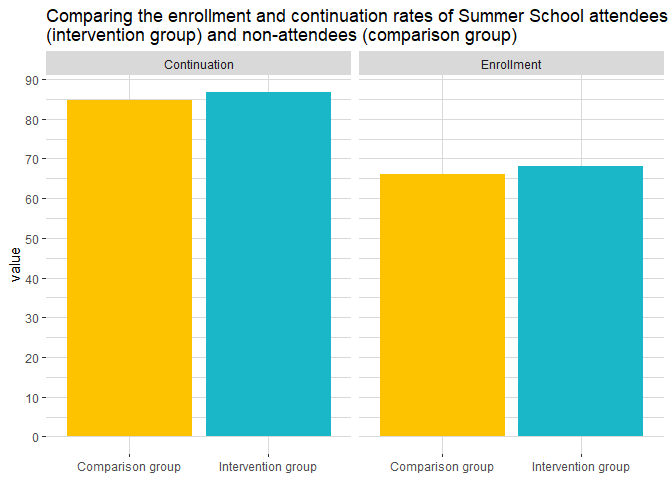

```r
enrol_cont <- bind_rows(
  descriptives$Enrollment %>%
    mutate(metric = "Enrollment", option = enrollment, value = perc_enrolled) %>%
    select(study_group, metric, option, value),
  descriptives$Continuation %>%
    mutate(metric = "Continuation", option = continued, value = perc_continued) %>%
    select(study_group, metric, option, value)) %>%
  filter(option == "enrolled" | option == "continued") %>%
  ggplot(aes(x = study_group, y = value, fill = study_group)) +
  geom_col(position = "dodge")+
  labs(title = "Comparing the enrollment and continuation rates of Summer School attendees\n(intervention group) and non-attendees (comparison group)",
       fill = "Group") +
  scale_y_continuous(n.breaks = 10) +
  scale_x_discrete(name = NULL,
                   labels = c("Comparison group", "Intervention group")) +
  scale_fill_manual(labels = c("Comparison group", "Intervention group"),
                    values = c("CG" = "#FDC300",
                               "IG" = "#1AB7C9")) +
  facet_grid(col = vars(metric)) +
  theme(legend.position = "none",
        panel.background = element_rect(fill = "white"),
        panel.grid.major = element_line(colour = "grey85"),
        panel.grid.minor = element_line(colour = "grey85"))
enrol_cont
```

[output not shown]

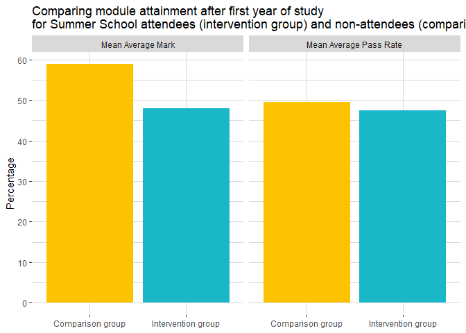

```r
marks_pass_rate <- bind_rows(
    descriptives$AvgPassRate %>%
      mutate(metric = "Mean Average Pass Rate", value = mean_pass_rate) %>%
      select(study_group, metric, value),
    descriptives$AvgMark %>%
      mutate(metric = "Mean Average Mark", value = mean_avg_mark) %>%
      select(study_group, metric, value)) %>%
  filter(!is.na(metric)) %>%
  ggplot(aes(x = study_group, y = value, fill = study_group)) +
  geom_col(position = "dodge") +
  labs(title = "Comparing module attainment after first year of study\nfor Summer School attendees (intervention group) and non-attendees (comparison group)",
       fill = "Group",
       ylab = "Percentage") +
  scale_y_continuous(name = "Percentage",
                     n.breaks = 10) +
  scale_x_discrete(name = NULL,
                   labels = c("Comparison group", "Intervention group")) +
  scale_fill_manual(labels = c("Comparison group", "Intervention group"),
                    values = c("CG" = "#FDC300",
                               "IG" = "#1AB7C9")) +
  facet_grid(col = vars(metric)) +
  theme(legend.position = "none",
        panel.background = element_rect(fill = "white"),
        panel.grid.major = element_line(colour = "grey85"),
        panel.grid.minor = element_line(colour = "grey85"))
marks_pass_rate
```

# 4 Statistical analysis: Evaluation of key academic outcomes

Statistical analysis of academic outcomes focused on the following evaluation questions:

- **EQ1**: Did attendance at the Summer School increase the likelihood of enrolling at the university of study?
- **EQ2**: Did Summer School attendees perform better academically than non-attendees?
- **EQ3**: Did attendance at the Summer School increase the likelihood of continuing into second year?

A range of different tests were used, appropriate to the original data, and are outlined in the sections below.

## 4.1 EQ1: Summer School attendance and enrollment

Several analysis techniques were used to explore relationships between Summer School attendance and enrollment at the institution of study. These were:

- Fisher’s exact test to measure association between study group and enrollment. Chosen for its suitability for small sample sizes and non-normally distributed categorical variables.
- Frequentist logistic regression to explore relationships between enrollment and study group.
- Bayesian logistic regression to validate findings from frequentist analysis. Employed due to better handling of small sample sizes compared to frequentist methods.

Please note, results below are based on synthetic data and are unlikely to match the original study.

### 4.1.1 Fisher’s exact test

Fisher’s exact test explored association in a 2 x 2 table, with IG set as row 1 and ‘enrolled’ set as column 1 to ensure that the test explored the odds of IG enrolling compared to CG.

```r
fishers_data_enroll <- combined_df %>%
  mutate(
    study_group = factor(study_group, levels = c("IG", "CG")),
    enrollment = factor(enrollment, levels = c("enrolled", "not enrolled"))
  ) %>%
  select(study_group, enrollment)
fishers_data_enroll <- table(fishers_data_enroll$study_group,fishers_data_enroll$enrollment)
fishers_data_enroll
```

```
##
##      enrolled not enrolled
##   IG       15            7
##   CG       33           17
```

```r
fishers_test_enroll <- fisher.test(fishers_data_enroll)
fishers_test_enroll
```

```
##
##  Fisher's Exact Test for Count Data
##
## data:  fishers_data_enroll
## p-value = 1
## alternative hypothesis: true odds ratio is not equal to 1
## 95 percent confidence interval:
##  0.3397313 3.8358161
## sample estimates:
## odds ratio
##   1.102361
```

### 4.1.2 Simple logistic regression

A simple logistic regression model was fitted to the data using both frequentist and Bayesian approaches, to explore the relationships between group members and enrollment.

Logistic regression estimated log-odds difference, with exponentiated coefficient giving an odds ratio showing the odds that IG would enroll compared to CG. 95% confidence intervals were calculated using Wald intervals based on the estimated standard error

Please note, results below are based on synthetic data and are unlikely to match results in the original study.

```r
combined_df_log <- combined_df %>%
  mutate(
    enrollment = if_else(enrollment == "enrolled", 1L, 0L),
    study_group_fact = factor(study_group, levels = c("IG", "CG")))
combined_df_log$study_group_fact <- relevel(combined_df_log$study_group_fact, ref = "CG") #Set CG as the reference so that coefficient is interpreted as IG vs CG.
str(combined_df_log)
```

```
## 'data.frame':    72 obs. of  8 variables:
##  $ study_id        : chr  "CG1" "CG2" "CG3" "CG4" ...
##  $ study_group     : chr  "CG" "CG" "CG" "CG" ...
##  $ enrollment      : int  1 1 0 0 1 1 1 1 1 1 ...
##  $ continued       : chr  "continued" "continued" "not enrolled" "not enrolled" ...
##  $ avg_mark        : num  65.2 61.9 NA NA 42.6 62.1 43.9 51.7 55.7 91.6 ...
##  $ avg_pass_rate   : num  61.7 28.6 NA NA 31.4 49.3 69.7 64.1 64.4 97.8 ...
##  $ survey_score    : num  4 4 4 3 3 5 5 3 4 3 ...
##  $ study_group_fact: Factor w/ 2 levels "CG","IG": 1 1 1 1 1 1 1 1 1 1 ...
```

```r
fmodel_enrollment <- glm(enrollment ~ study_group_fact, data = combined_df_log, family = binomial)
summary(fmodel_enrollment)
```

```
##
## Call:
## glm(formula = enrollment ~ study_group_fact, family = binomial,
##     data = combined_df_log)
##
## Coefficients:
##                    Estimate Std. Error z value Pr(>|z|)
## (Intercept)         0.66329    0.29854   2.222   0.0263 *
## study_group_factIG  0.09885    0.54649   0.181   0.8565
## ---
## Signif. codes:  0 '***' 0.001 '**' 0.01 '*' 0.05 '.' 0.1 ' ' 1
##
## (Dispersion parameter for binomial family taken to be 1)
##
##     Null deviance: 91.658  on 71  degrees of freedom
## Residual deviance: 91.625  on 70  degrees of freedom
## AIC: 95.625
##
## Number of Fisher Scoring iterations: 4
```

```r
#odds ratio for IG vs CG
beta_fmodel_simple <- coef(fmodel_enrollment)["study_group_factIG"]
OR_fmodel_simple <- exp(beta_fmodel_simple)
OR_fmodel_simple
```

```
## study_group_factIG
##           1.103896
```

```r
se_fmodel_simple <- sqrt(vcov(fmodel_enrollment)["study_group_factIG", "study_group_factIG"])
CI_OR_fmodel_simple <- exp(beta_fmodel_simple + c(-1, 1) * 1.96 * se_fmodel_simple)
CI_OR_fmodel_simple
```

```
## [1] 0.3782225 3.2218775
```

A simple Bayesian logistic regression model was fitted as a robustness check alongside the frequentist analysis. This approach was chosen due to the relatively small sample size and quasi-experimental design, where maximum-likelihood estimates can be unstable.

This model used the following:

- Weakly informative priors were used for all regression parameters to help stabilise small samples without imposing strong assumptions. These priors assume that effects are most likely to be close to zero, while still allowing a wide range of plausible values if supported by the data.
- Weakly informative intercept prior was used to reflect uncertainty about baseline enrollment rate, while avoiding implausible extremes.
- MCMC sampling was used, with four chains run each with 2000 iterations. Convergence was assessed using standard diagnostics to ensure that posterior estimates were stable.

Odds ratios, posterior means, and 95% credible intervals were reported, with the direction of the effect described using the proportion of posterior draws.

The example below is illustrative only and will differ from the results of the original study.

```r
bmodel_enrollment <- stan_glm(enrollment ~ study_group_fact,
                              data = combined_df_log,
                              family = binomial(link = "logit"),
                              prior = normal(location = 0, scale = 2.5, autoscale = FALSE),
                              prior_intercept = normal(location = 0, scale = 2.5, autoscale = FALSE),
                              chains = 4, iter = 2000, seed = 123, refresh = 0)
print(summary(bmodel_enrollment), digits = 4)
```

```
##
## Model Info:
##  function:     stan_glm
##  family:       binomial [logit]
##  formula:      enrollment ~ study_group_fact
##  algorithm:    sampling
##  sample:       4000 (posterior sample size)
##  priors:       see help('prior_summary')
##  observations: 72
##  predictors:   2
##
## Estimates:
##                      mean    sd      10%     50%     90%
## (Intercept)         0.6748  0.3022  0.2905  0.6803  1.0632
## study_group_factIG  0.1088  0.5591 -0.6007  0.1047  0.8325
##
## Fit Diagnostics:
##            mean   sd     10%    50%    90%
## mean_PPD 0.6669 0.0772 0.5694 0.6667 0.7639
##
## The mean_ppd is the sample average posterior predictive distribution of the outcome variable (for details see help('summary.stanreg')).
##
## MCMC diagnostics
##                    mcse   Rhat   n_eff
## (Intercept)        0.0059 0.9995 2668
## study_group_factIG 0.0119 1.0007 2223
## mean_PPD           0.0013 0.9993 3365
## log-posterior      0.0238 1.0034 1835
##
## For each parameter, mcse is Monte Carlo standard error, n_eff is a crude measure of effective sample size, and Rhat is the potential scale reduction factor on split chains (at convergence Rhat=1).
```

```r
#odds ratio for IG vs CG
post_bmodel_simple <- as.matrix(bmodel_enrollment)
beta_IG_bmodel_simple <- post_bmodel_simple[,"study_group_factIG"]
OR_bmodel_simple <- exp(beta_IG_bmodel_simple)
OR_simple_summary <- c(
  mean = mean(OR_bmodel_simple),
  median = median(OR_bmodel_simple),
  quantile(OR_bmodel_simple, c(`2.5%` = 0.025, `97.5%` = 0.975))
)
OR_simple_summary
```

```
##      mean    median      2.5%     97.5%
## 1.3088467 1.1103235 0.3821909 3.4382708
```

```r
pd_negative_simple <- mean(beta_IG_bmodel_simple < 0)
pd_positive_simple <- mean(beta_IG_bmodel_simple > 0)
pd_negative_simple;pd_positive_simple
```

```
## [1] 0.42725
```

```
## [1] 0.57275
```

```r
#convergence checks
diag_simple <- summary(bmodel_enrollment)[, c("Rhat", "n_eff", "mcse")]
diag_simple
```

```
##                         Rhat n_eff        mcse
## (Intercept)        0.9995353  2668 0.005851123
## study_group_factIG 1.0006567  2223 0.011858540
## mean_PPD           0.9993015  3365 0.001331284
## log-posterior      1.0033721  1835 0.023797065
```

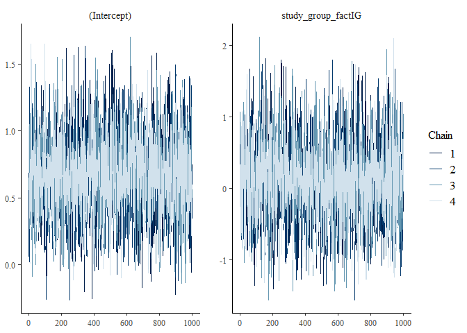

```r
plot(bmodel_enrollment, "trace")
```

### 4.1.3 Adjusted models

Additional models to those presented below were tested, including taking demographic characteristics and further baseline survey results as additional covariates. These were not retained for reporting due to limited sample size and minimal impact on the estimated association between Summer School attendance and enrollment. They are omitted here for clarity.

Models outlined below are for illustrative purposes only and do not reflect the findings from the original study.

```r
fmodel_enrollment_survey <- glm(enrollment ~ study_group_fact + survey_score, data = combined_df_log, family = binomial)
summary(fmodel_enrollment_survey)
```

```
##
## Call:
## glm(formula = enrollment ~ study_group_fact + survey_score, family = binomial,
##     data = combined_df_log)
##
## Coefficients:
##                    Estimate Std. Error z value Pr(>|z|)
## (Intercept)         -0.5422     1.3626  -0.398    0.691
## study_group_factIG   0.1997     0.5632   0.355    0.723
## survey_score         0.3001     0.3327   0.902    0.367
##
## (Dispersion parameter for binomial family taken to be 1)
##
##     Null deviance: 91.658  on 71  degrees of freedom
## Residual deviance: 90.798  on 69  degrees of freedom
## AIC: 96.798
##
## Number of Fisher Scoring iterations: 4
```

```r
#odds ratio for IG vs CG
beta_fmodel_adjusted <- coef(fmodel_enrollment_survey)["study_group_factIG"]
OR_fmodel_adjusted <- exp(beta_fmodel_adjusted)
OR_fmodel_adjusted
```

```
## study_group_factIG
##           1.221004
```

```r
se_fmodel_adjusted <- sqrt(vcov(fmodel_enrollment_survey)["study_group_factIG", "study_group_factIG"])
CI_OR_fmodel_adjusted <- exp(beta_fmodel_adjusted + c(-1, 1) * 1.96 * se_fmodel_adjusted)
CI_OR_fmodel_adjusted
```

```
## [1] 0.4048794 3.6822118
```

The adjusted Bayesian model outlined below used weakly informative priors for both the regression coefficients and the intercept, reflecting uncertainty about the magnitude and direction of the effects, as well as baseline enrollment probability.

```r
bmodel_enrollment_survey <- stan_glm(enrollment ~ study_group_fact + survey_score,
                                     data = combined_df_log,
                                     family = binomial(link = "logit"),
                                    prior = normal(location = 0, scale = 2.5, autoscale = FALSE),
                                    prior_intercept = normal(location = 0, scale = 2.5, autoscale = FALSE),
                                    chains = 4, iter = 2000, seed = 123, refresh = 0)
print(summary(bmodel_enrollment_survey), digits = 4)
```

```
##
## Model Info:
##  function:     stan_glm
##  family:       binomial [logit]
##  formula:      enrollment ~ study_group_fact + survey_score
##  algorithm:    sampling
##  sample:       4000 (posterior sample size)
##  priors:       see help('prior_summary')
##  observations: 72
##  predictors:   3
##
## Estimates:
##                      mean    sd      10%     50%     90%
## (Intercept)        -0.5752  1.3972 -2.3771 -0.5864  1.2205
## study_group_factIG  0.2267  0.5686 -0.4799  0.2187  0.9635
## survey_score        0.3116  0.3418 -0.1247  0.3110  0.7546
##
## Fit Diagnostics:
##            mean   sd     10%    50%    90%
## mean_PPD 0.6644 0.0782 0.5556 0.6667 0.7639
##
## The mean_ppd is the sample average posterior predictive distribution of the outcome variable (for details see help('summary.stanreg')).
##
## MCMC diagnostics
##                    mcse   Rhat   n_eff
## (Intercept)        0.0233 1.0008 3590
## study_group_factIG 0.0093 0.9996 3745
## survey_score       0.0058 1.0011 3525
## mean_PPD           0.0013 1.0003 3668
## log-posterior      0.0313 0.9999 1704
##
## For each parameter, mcse is Monte Carlo standard error, n_eff is a crude measure of effective sample size, and Rhat is the potential scale reduction factor on split chains (at convergence Rhat=1).
```

```r
#odds ratio for IG vs CG
post_bmodel_adjusted <- as.matrix(bmodel_enrollment_survey)
beta_IG_bmodel_adjusted <- post_bmodel_adjusted[,"study_group_factIG"]
OR_bmodel_adjusted <- exp(beta_IG_bmodel_adjusted)
OR_adjusted_summary <- c(
  mean = mean(OR_bmodel_adjusted),
  median = median(OR_bmodel_adjusted),
  quantile(OR_bmodel_adjusted, c(`2.5%` = 0.025, `97.5%` = 0.975))
)
OR_adjusted_summary
```

```
##     mean   median     2.5%    97.5%
## 1.478246 1.244492 0.419175 3.918400
```

```r
pd_negative_adjusted <- mean(beta_IG_bmodel_adjusted < 0)
pd_positive_adjusted <- mean(beta_IG_bmodel_adjusted > 0)
pd_negative_adjusted;pd_positive_adjusted
```

```
## [1] 0.35025
```

```
## [1] 0.64975
```

```r
#convergence checks
diag_adjusted <- summary(bmodel_enrollment_survey)[, c("Rhat", "n_eff", "mcse")]
diag_adjusted
```

```
##                         Rhat n_eff        mcse
## (Intercept)        1.0008167  3590 0.023319382
## study_group_factIG 0.9996449  3745 0.009291292
## survey_score       1.0010545  3525 0.005756043
## mean_PPD           1.0002615  3668 0.001290973
## log-posterior      0.9998832  1704 0.031272798
```

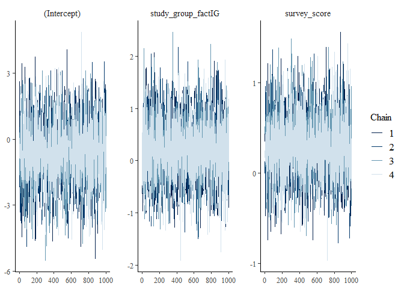

```r
plot(bmodel_enrollment_survey, "trace")
```

## 4.2 EQ2: Summer School attendance and attainment

Tests were run to determine if there was any significant association between Summer School attendance and academic attainment. These tests are restricted to participants who enrolled at the institution of study.

The following tests were run in addition to descriptive analysis findings observed above:

- Shapiro-Wilks test for normality. In the original study, average mark was normally distributed and pass rate was not, affecting which tests where subsequently used. This notebook follows the original study’s workflow, which may not match the synthetically generated data used here.
- T-test to explore compare IG and CG means for average mark. In the original study, no significant difference was found.
- Mann-Whitney U test to compare distribution of IG and CG average pass rates. In the original study, no significant difference was found.

```r
avg_mark <- combined_df %>%
  filter(!is.na(avg_mark))

shapiro.test(avg_mark$avg_mark)
```

```
##
##  Shapiro-Wilk normality test
##
## data:  avg_mark$avg_mark
## W = 0.94527, p-value = 0.02599
```

```r
ttest_avg_mark <- t.test(avg_mark ~ study_group, data = avg_mark, var.equal = FALSE)
ttest_avg_mark
```

```
##
##  Welch Two Sample t-test
##
## data:  avg_mark by study_group
## t = 2.3281, df = 32.298, p-value = 0.02633
## alternative hypothesis: true difference in means between group CG and group IG is not equal to 0
## 95 percent confidence interval:
##   1.380671 20.643572
## sample estimates:
## mean in group CG mean in group IG
##         58.91212         47.90000
```

```r
pass_rate <- combined_df %>%
  filter(!is.na(avg_pass_rate))

shapiro.test(pass_rate$avg_pass_rate)
```

```
##
##  Shapiro-Wilk normality test
##
## data:  pass_rate$avg_pass_rate
## W = 0.95263, p-value = 0.05092
```

```r
mann_whit_pass_rate <- wilcox.test(avg_pass_rate ~ study_group, data = pass_rate)
mann_whit_pass_rate
```

```
##
##  Wilcoxon rank sum exact test
##
## data:  avg_pass_rate by study_group
## W = 257, p-value = 0.8431
## alternative hypothesis: true location shift is not equal to 0
```

## 4.3 EQ3: Summer School attendance and continuation

Fisher’s exact test was run to explore association in a 2 x 2 table, with IG set as row 1 and ‘continued’ set as column 1 to ensure that the test explored the odds of IG continuing compared to CG. These tests are restricted to participants who enrolled at the institution of study.

In the original study, descriptive analysis showed a higher continuation rate for IG compared to CG, but Fisher’s exact test showed this was not a statistically significant result and no further tests were run.

Results below will be based on the synthetic data used in this notebook and will likely differ from the results of the original study.

```r
fishers_data_continuation <- combined_df %>%
  filter(continued != "not enrolled") %>%
  mutate(
    study_group = factor(study_group, levels = c("IG", "CG")),
    continued = factor(continued, levels = c("continued", "not continued"))
  ) %>%
  select(study_group, continued)
fishers_data_continuation <- table(fishers_data_continuation$study_group,fishers_data_continuation$continued)
fishers_data_continuation
```

```
##
##      continued not continued
##   IG        13             2
##   CG        28             5
```

```r
fishers_test_continuation <- fisher.test(fishers_data_continuation)
fishers_test_continuation
```

```
##
##  Fisher's Exact Test for Count Data
##
## data:  fishers_data_continuation
## p-value = 1
## alternative hypothesis: true odds ratio is not equal to 1
## 95 percent confidence interval:
##   0.1614154 13.6839689
## sample estimates:
## odds ratio
##   1.157219
```